# Reproducible Research Peer Grading Assignment.Rmd

shas

01-08-2021

Loading and preprocessing the data:

```r
library(dplyr)
library(ggplot2)
library(skimr)
library(Hmisc)
library(lubridate)

Sys.setlocale("LC_TIME", "English")
```

```
## [1] "English_United States.1252"
```

```r
data <- read.csv("activity.csv", header = TRUE, na.strings=c("",".","NA"))
head(data)
```

```
##   steps       date interval
## 1    NA 2012-10-01        0
## 2    NA 2012-10-01        5
## 3    NA 2012-10-01       10
## 4    NA 2012-10-01       15
## 5    NA 2012-10-01       20
## 6    NA 2012-10-01       25
```

```r
str(data)
```

```
## 'data.frame':    17568 obs. of  3 variables:
##  $ steps   : int  NA NA NA NA NA NA NA NA NA NA ...
##  $ date    : chr  "2012-10-01" "2012-10-01" "2012-10-01" "2012-10-01" ...
##  $ interval: int  0 5 10 15 20 25 30 35 40 45 ...
```

## What is mean total number of steps taken per day?

```r
total_steps <- data %>%
    group_by(date) %>%
    summarise(daily_steps = sum(steps))

head(total_steps)
```

```
## # A tibble: 6 x 2
##   date       daily_steps
##   <chr>            <int>
## 1 2012-10-01          NA
## 2 2012-10-02         126
## 3 2012-10-03       11352
## 4 2012-10-04       12116
## 5 2012-10-05       13294
## 6 2012-10-06       15420
```

Histogram of total number of steps taken per day:

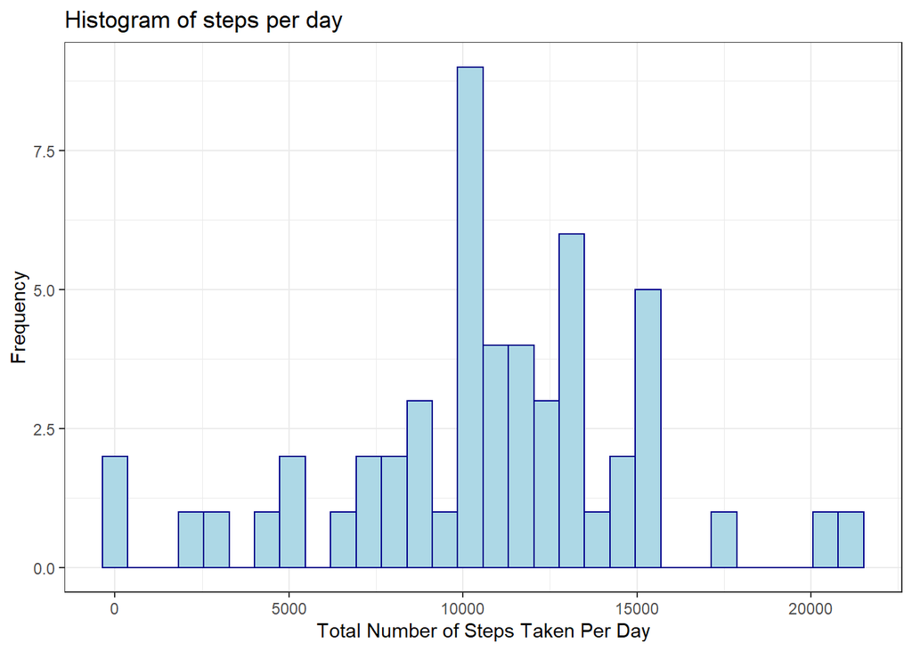

```r
ggplot(data = total_steps, aes(daily_steps)) +
    geom_histogram(col="darkblue", fill="lightblue") +
    ggtitle("Histogram of steps per day") +
    xlab("Total Number of Steps Taken Per Day") +
    ylab("Frequency") +
    theme_bw()
```

## Mean and median number of steps taken each day:

```r
mean(total_steps$daily_steps, na.rm = TRUE)
```

```
## [1] 10766.19
```

```r
median(total_steps$daily_steps, na.rm = TRUE)
```

```
## [1] 10765
```

## The 5-minute interval that, on average, contains the maximum number of steps

```r
average_interval_steps <- data %>%
    group_by(interval) %>%
    summarise(average_steps = mean(steps, na.rm = TRUE))
```

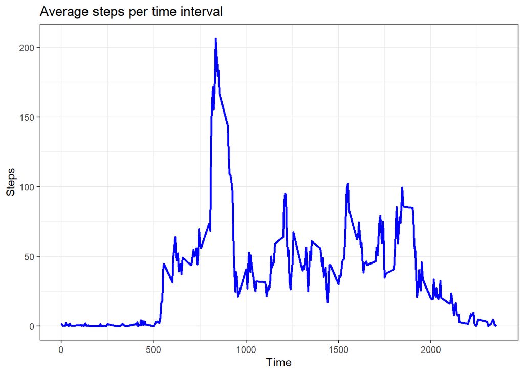

```r
ggplot(data = average_interval_steps, aes(x = interval, y = average_steps)) +
    geom_line(color = "blue", size = 1) +
    ggtitle("Average steps per time interval") +
    xlab("Time") +
    ylab("Steps") +
    theme_bw()
```

## 5-minute interval that contains the maximum number of steps is the 835th interval.

```r
average_interval_steps[which.max(average_interval_steps$average_steps),]$interval
```

```
## [1] 835
```

## Code to describe and show a strategy for imputing missing data:

```r
str(data)
```

```
## 'data.frame':    17568 obs. of  3 variables:
##  $ steps   : int  NA NA NA NA NA NA NA NA NA NA ...
##  $ date    : chr  "2012-10-01" "2012-10-01" "2012-10-01" "2012-10-01" ...
##  $ interval: int  0 5 10 15 20 25 30 35 40 45 ...
```

```r
skim_without_charts(data)
```

Data summary

| Name | data |
| --- | --- |
| Number of rows | 17568 |
| Number of columns | 3 |
| _______________________ |  |
| Column type frequency: |  |
| character | 1 |
| numeric | 2 |
| ________________________ |  |
| Group variables | None |

**Variable type: character**

| skim_variable | n_missing | complete_rate | min | max | empty | n_unique | whitespace |
| --- | --- | --- | --- | --- | --- | --- | --- |
| date | 0 | 1 | 10 | 10 | 0 | 61 | 0 |

**Variable type: numeric**

| skim_variable | n_missing | complete_rate | mean | sd | p0 | p25 | p50 | p75 | p100 |
| --- | --- | --- | --- | --- | --- | --- | --- | --- | --- |
| steps | 2304 | 0.87 | 37.38 | 112.00 | 0 | 0.00 | 0.0 | 12.00 | 806 |
| interval | 0 | 1.00 | 1177.50 | 692.45 | 0 | 588.75 | 1177.5 | 1766.25 | 2355 |

“Steps” variable has 2304 missing values

I will replace the missing values in “steps” variable with the average values of it. First I created a new variable “activity” that is the same as the original data, then filled the missing values with the average values in “steps” variable, which is 37.3826

```r
activity <- data

activity$steps <- impute(data$steps, fun = mean)
```

## Histogram of the total number of steps taken each day after missing values are imputed:

```r
imputed_total_steps <- activity %>%
    group_by(date) %>%
    summarise(imputed_total_steps = sum(steps))
```

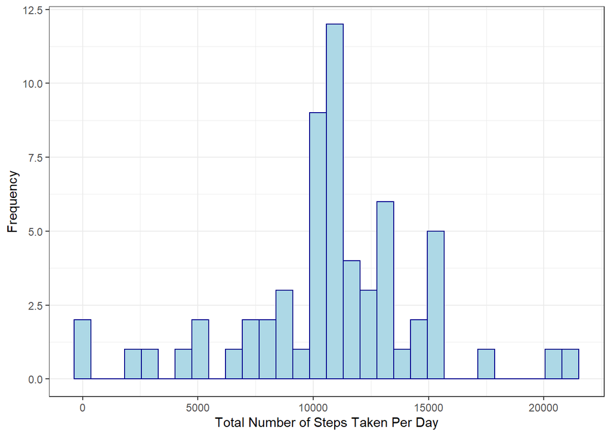

```r
ggplot(data = imputed_total_steps , aes(imputed_total_steps)) +
    geom_histogram(col="darkblue", fill="lightblue") +
    xlab("Total Number of Steps Taken Per Day") +
    ylab("Frequency") +
    theme_bw()
```

```r
mean(imputed_total_steps$imputed_total_steps, na.rm = TRUE)
```

```
## [1] 10766.19
```

```r
median(imputed_total_steps$imputed_total_steps, na.rm = TRUE)
```

```
## [1] 10766.19
```

After filling the missing values, unsurprisingly, the mean value of steps didn’t change because I filled the missing values with the average value. But the median value changed from 10765 to 10766.19.

## Panel plot comparing the average number of steps taken per 5-minute interval across weekdays and weekends:

```r
day_of_week <- activity %>%
    mutate(
        date = ymd(date),
        weekday_or_weekend = case_when(wday(date) %in% 2:6 ~ "Weekday",
                                       wday(date) %in% c(1,7) ~ "Weekend")
    ) %>%
    group_by(interval, weekday_or_weekend) %>%
    summarise(
        steps = mean(steps)
    )
```

```r
head(day_of_week)
```

```
## # A tibble: 6 x 3
## # Groups:   interval [3]
##   interval weekday_or_weekend steps
##      <int> <chr>              <dbl>
## 1        0 Weekday             7.01
## 2        0 Weekend             4.67
## 3        5 Weekday             5.38
## 4        5 Weekend             4.67
## 5       10 Weekday             5.14
## 6       10 Weekend             4.67
```

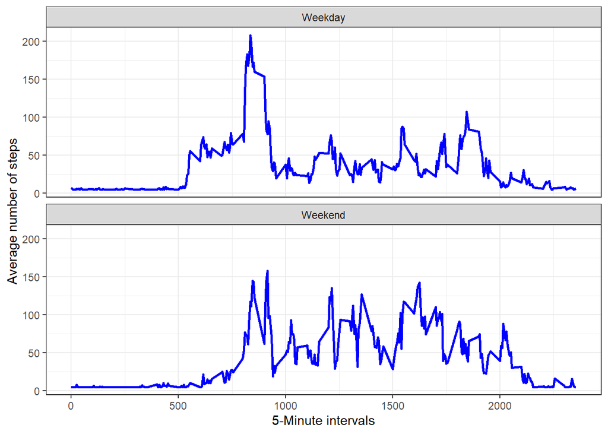

```r
ggplot(day_of_week, aes(interval, steps)) +
    geom_line(color = "blue", size = 1) +
    facet_wrap(~weekday_or_weekend, nrow = 2, ncol = 1) +
    xlab("5-Minute intervals") +
    ylab("Average number of steps") +
    theme_bw()
```